# SpaDESinAction

Tati Micheletti

August 18, 2019

## Integrated simulation models: fire, harvesting, birds and caribou

The present toy model is an exercise to understand how SpaDES works when integrating different modules. It is composed of 4 main models (with one to several submodules within each):

### Running the simulations

#### 1. Setting up all necessary packages, paths and loading all necessary libraries

When setting up the paths using the `SpaDES.core` function `setPaths()`, note that the modules folder should point to where all your modules’ *folders* are. SpaDES will find all of these by their names.

```r
devtools::install_github("PredictiveEcology/SpaDES.core", ref = "development")
devtools::install_github("PredictiveEcology/SpaDES.tools", ref = "development")
devtools::install_github("PredictiveEcology/reproducible", ref = "development")
devtools::install_github("PredictiveEcology/reproducible", ref = "development")
devtools::install_github("tati-micheletti/usefun")

# Set a few options
options(spades.lowMemory = TRUE)
options(spades.moduleCodeChecks = FALSE)

# Load libraries
  library("SpaDES")
  library("magrittr")
  library("raster")

# Set the directories
  workDirectory <- getwd()

    SpaDES.core::setPaths(
           modulePath = file.path(workDirectory, "modules"),
           inputPath = file.path(workDirectory, "inputs"),
           outputPath = file.path(workDirectory, "outputs"),
           cachePath = file.path(workDirectory, "cache"))
```

#### 2. Setting up all inputs for the simulation runs

To setup the simulation, we will set 3 ‘inputs’ for the model:

1. **TIME**: start by setting the time for how long you want to run the simulations for. This needs to be a list, in the format of `list(start = 0, end = 10)`.
2. **PARAMETERS**: Next, pass the values of any parameters you would like to change. These values should be a `list()` of the name of the module that contains these. For example, if you want to modify how often the bird model should be run (by default only happening in the beginning and end of the simulation), you can pass inside the parameters list the following: `birdsAlberta = list(.plotInterval = 5)`, for it to run every 5 years. You can find all parameters that can be changed in the metadata of each module, together with a default value and the description of what that parameter does.
3. **OBJECTS**: At last, pass any objects you might want to override from the defaults. One example is the study area. You can load a shapefile in R, and pass it in the form `list(studyArea = shapefile)`. The names of all objects passed need to match the names these have in the modules. These can also be found in the metadata of each module.

It is interesting to note that while **objects are shared** accross modules, **parameters are not**. The modules are in fact integrated by the objects these use as *inputs* and objects these produce as *outputs*. These also have to be defined in the metadata.

Module developers should provide default values for all parameters and objetcs, even if the objects are expected as inputs. This guarantees that anyone running your module, even without any data, is capable of seeing it work.

```r
times <- list(start = 0, end = 10)
parameters <- list()
objects <- list()
```

#### 3. Setting up the modules

**MODULES**: The last step to run the simulation is to identify which modules you want to run together. This should also be passed as a list of the modules names i.e. list(“module1”, “module2”, “module3”).

Here, we will mix and match a set of different modules to demonstrate the power of SpaDES. First, we will run a fire model, followed by a harvesting model, and at last, an integrated model that has fire, harvesting, birds and caribous.

```r
modulesFire <- list("scfmLandcoverInit", "scfmRegime",
                    "scfmDriver", "scfmIgnition",
                    "scfmEscape", "scfmSpread")

modulesHarvest <- list("scfmLandcoverInit", "loadYieldTables",
                       "Hanzlik", "strataMapFromVegMap",
                       "scfmHarvest", "stateVars")

allModules <- list("scfmLandcoverInit", "scfmRegime",
                   "scfmDriver", "scfmIgnition",
                   "scfmEscape", "scfmSpread", # Fire model
                   "loadYieldTables", "Hanzlik",
                   "strataMapFromVegMap", "scfmHarvest", # Harvesting
                   "stateVars", # Updating maps and variables
                   "birdsAlberta", # Bird model
                   "caribouAlberta") # Caribou population model
```

#### 4. SpaDES in ACTION!

At last, we will run the simulation calling the `simInitAndSpades()` function. This function needs as inputs the paths, times, parameters, objects, and modules, apart from the *loadOrder* of the modules. If the load order is not provided, the modules might be loaded in a different order than these are supposed to, which might return an error due to missing objects.

##### **FIRE**

First, we will run the fire model:

```r
FIREinAction <- simInitAndSpades(times = times,
                                   params = parameters,
                                   modules = modulesFire,
                                   objects = objects,
                                   paths = getPaths(),
                                   loadOrder = unlist(modulesFire))
```

```
## [1] "downloading NFDB"
## [1] "2019-08-17 16:29:06 | total elpsd: 0.003 secs | 0 checkpoint init 5"
## [1] "2019-08-17 16:29:06 | total elpsd: 0.005 secs | 0 save init 5"
## [1] "2019-08-17 16:29:06 | total elpsd: 0.008 secs | 0 progress init 5"
## [1] "2019-08-17 16:29:06 | total elpsd: 0.01 secs | 0 load init 5"
## [1] "2019-08-17 16:29:06 | total elpsd: 0.016 secs | 0 scfmLandcoverInit init 5"
## [1] "2019-08-17 16:29:07 | total elpsd: 0.76 secs | 0 scfmRegime init 5"
## [1] "2019-08-17 16:29:07 | total elpsd: 0.83 secs | 0 scfmDriver init 5"
## [1] "2019-08-17 16:29:09 | total elpsd: 2.9 secs | 0 scfmIgnition init 5"
## [1] "2019-08-17 16:29:09 | total elpsd: 2.9 secs | 0 scfmEscape init 5"
## [1] "2019-08-17 16:29:09 | total elpsd: 2.9 secs | 0 scfmSpread init 5"
## [1] "2019-08-17 16:29:09 | total elpsd: 2.9 secs | 0 scfmLandcoverInit plot 5"
```

```
## [1] "2019-08-17 16:29:09 | total elpsd: 3.3 secs | 0 scfmIgnition ignite 7.5"
## [1] "2019-08-17 16:29:09 | total elpsd: 3.3 secs | 0 scfmEscape escape 7.5"
## [1] "2019-08-17 16:29:09 | total elpsd: 3.3 secs | 0 scfmSpread burn 7.5"
## [1] "2019-08-17 16:29:10 | total elpsd: 3.9 secs | 1 scfmIgnition ignite 7.5"
## [1] "2019-08-17 16:29:10 | total elpsd: 3.9 secs | 1 scfmEscape escape 7.5"
## [1] "2019-08-17 16:29:10 | total elpsd: 4 secs | 1 scfmSpread burn 7.5"
## [1] "2019-08-17 16:29:10 | total elpsd: 4.6 secs | 1 scfmSpread plot 8"
```

```
## [1] "2019-08-17 16:29:12 | total elpsd: 6.3 secs | 2 scfmIgnition ignite 7.5"
## [1] "2019-08-17 16:29:12 | total elpsd: 6.3 secs | 2 scfmEscape escape 7.5"
## [1] "2019-08-17 16:29:12 | total elpsd: 6.3 secs | 2 scfmSpread burn 7.5"
## [1] "2019-08-17 16:29:13 | total elpsd: 7 secs | 2 scfmSpread plot 8"
## [1] "2019-08-17 16:29:14 | total elpsd: 7.8 secs | 3 scfmIgnition ignite 7.5"
## [1] "2019-08-17 16:29:14 | total elpsd: 7.8 secs | 3 scfmEscape escape 7.5"
## [1] "2019-08-17 16:29:14 | total elpsd: 7.8 secs | 3 scfmSpread burn 7.5"
## [1] "2019-08-17 16:29:14 | total elpsd: 7.8 secs | 3 scfmSpread plot 8"
## [1] "2019-08-17 16:29:14 | total elpsd: 8.6 secs | 4 scfmIgnition ignite 7.5"
## [1] "2019-08-17 16:29:14 | total elpsd: 8.6 secs | 4 scfmEscape escape 7.5"
## [1] "2019-08-17 16:29:15 | total elpsd: 8.7 secs | 4 scfmSpread burn 7.5"
## [1] "2019-08-17 16:29:15 | total elpsd: 8.7 secs | 4 scfmSpread plot 8"
## [1] "2019-08-17 16:29:15 | total elpsd: 9.5 secs | 5 scfmIgnition ignite 7.5"
## [1] "2019-08-17 16:29:15 | total elpsd: 9.5 secs | 5 scfmEscape escape 7.5"
## [1] "2019-08-17 16:29:15 | total elpsd: 9.5 secs | 5 scfmSpread burn 7.5"
```

[output cut: 21 more lines]

Note that you can see all events happening, as well as any messages printed during the simulation. Really handy is also to see all plots while the simulation is running. This is really helpful to visually identify potential problems even before the simulation ends.

We can also see some of the fire statistics such as:

1. Summary of burns

```r
# Fire Summary
knitr::kable(FIREinAction$burnSummary)
```

| igLoc | N | year | areaBurned | polyID |
| --- | --- | --- | --- | --- |
| 1416 | 1 | 0 | 100 | 108 |
| 2999 | 1 | 0 | 100 | 108 |
| 6020 | 1 | 0 | 100 | 108 |
| 6632 | 1 | 0 | 100 | 108 |
| 7386 | 1 | 0 | 100 | 108 |
| 8604 | 1 | 0 | 100 | 108 |
| 9248 | 3 | 0 | 300 | 108 |
| 10050 | 1 | 0 | 100 | 108 |
| 14322 | 1 | 0 | 100 | 108 |
| 15285 | 1 | 0 | 100 | 108 |
| 19554 | 1 | 0 | 100 | 108 |
| 20793 | 1 | 0 | 100 | 108 |
| 22606 | 1 | 0 | 100 | 108 |
| 22834 | 1 | 0 | 100 | 108 |
| 23064 | 1 | 0 | 100 | 108 |
| 23258 | 1 | 0 | 100 | 108 |
| 23524 | 1 | 0 | 100 | 108 |
| 25641 | 1 | 0 | 100 | 108 |
| 26749 | 1 | 0 | 100 | 108 |
| 30565 | 1 | 0 | 100 | 108 |
| 3655 | 2 | 1 | 200 | 108 |
| 5288 | 1 | 1 | 100 | 108 |
| 7607 | 13 | 1 | 1300 | 108 |
| 9788 | 1 | 1 | 100 | 108 |
| 11773 | 1 | 1 | 100 | 108 |
| 12153 | 1 | 1 | 100 | 108 |
| 12305 | 2 | 1 | 200 | 108 |
| 12388 | 1 | 1 | 100 | 108 |
| 12983 | 1 | 1 | 100 | 108 |
| 14354 | 1 | 1 | 100 | 108 |

[output cut: 158 more lines]

2. Probability of ignition of a pixel

```r
# Fire Summary
print(FIREinAction$pIg)
```

```
## [1] 0.001356465
```

3. Fire driver parameters

```r
# Fire Summary
FIREinAction$scfmDriverPars$`108`
```

```
## $pSpread
## [1] 0.2142647
##
## $p0
## [1] 0.007253892
##
## $naiveP0
## [1] 0.006775093
##
## $pIgnition
## [1] 0.001356465
##
## $maxBurnCells
## [1] 9589
##
## $calibModel
##
## Family: gaussian
## Link function: identity
##
## Formula:
## finalSize ~ s(p, bs = "micx", k = 20)
## <environment: 0x000000002acb95f8>
##
## Estimated degrees of freedom:
## 3.84  total = 4.84
##
## GCV score: 73388180
##
##
## $uniroot.Res
## $uniroot.Res$root
## [1] 0.2142647
##
## $uniroot.Res$f.root
##            1
## -0.009185319
##
## $uniroot.Res$iter
## [1] 7
##
## $uniroot.Res$init.it
## [1] NA
##
## $uniroot.Res$estim.prec
## [1] 5e-06
```

##### HARVEST

Now, we will run the harvest model:

```r
HARVESTinAction <- simInitAndSpades(times = times,
                                   params = parameters,
                                   modules = modulesHarvest,
                                   objects = objects,
                                   paths = getPaths(),
                                   loadOrder = unlist(modulesHarvest))
```

```
## [1] "2019-08-17 16:29:30 | total elpsd: 0.002 secs | 0 checkpoint init 5"
## [1] "2019-08-17 16:29:30 | total elpsd: 0.003 secs | 0 save init 5"
## [1] "2019-08-17 16:29:30 | total elpsd: 0.007 secs | 0 progress init 5"
## [1] "2019-08-17 16:29:30 | total elpsd: 0.009 secs | 0 load init 5"
## [1] "2019-08-17 16:29:30 | total elpsd: 0.015 secs | 0 scfmLandcoverInit init 5"
## [1] "2019-08-17 16:29:32 | total elpsd: 1.3 secs | 0 loadYieldTables init 5"
## [1] "2019-08-17 16:29:32 | total elpsd: 1.3 secs | 0 Hanzlik init 5"
## [1] "2019-08-17 16:29:32 | total elpsd: 1.3 secs | 0 strataMapFromVegMap init 5"
## [1] "2019-08-17 16:29:32 | total elpsd: 1.6 secs | 0 scfmHarvest init 5"
## [1] "2019-08-17 16:29:32 | total elpsd: 1.6 secs | 0 stateVars init 5"
## [1] "2019-08-17 16:29:32 | total elpsd: 1.6 secs | 0 scfmLandcoverInit plot 5"
## [1] "2019-08-17 16:29:32 | total elpsd: 1.9 secs | 0 Hanzlik plan 5"
## [1] "2019-08-17 16:29:32 | total elpsd: 1.9 secs | 0 strataMapFromVegMap plot 5"
```

```
## [1] "2019-08-17 16:29:33 | total elpsd: 2.4 secs | 0 scfmHarvest plot 5"
## [1] "2019-08-17 16:29:33 | total elpsd: 2.4 secs | 0 stateVars update 5"
## [1] "2019-08-17 16:29:33 | total elpsd: 2.5 secs | 0 stateVars plot 5"
## [1] "2019-08-17 16:29:33 | total elpsd: 2.5 secs | 1 scfmHarvest harvest 5"
## [1] "2019-08-17 16:29:33 | total elpsd: 2.9 secs | 1 scfmHarvest plot 5"
## [1] "2019-08-17 16:29:33 | total elpsd: 2.9 secs | 1 stateVars update 5"
## [1] "2019-08-17 16:29:33 | total elpsd: 3 secs | 1 stateVars plot 5"
## [1] "2019-08-17 16:29:33 | total elpsd: 3 secs | 2 scfmHarvest harvest 5"
## [1] "2019-08-17 16:29:34 | total elpsd: 3.4 secs | 2 scfmHarvest plot 5"
## [1] "2019-08-17 16:29:34 | total elpsd: 3.4 secs | 2 stateVars update 5"
## [1] "2019-08-17 16:29:34 | total elpsd: 3.5 secs | 2 stateVars plot 5"
## [1] "2019-08-17 16:29:34 | total elpsd: 3.5 secs | 3 scfmHarvest harvest 5"
## [1] "2019-08-17 16:29:34 | total elpsd: 3.9 secs | 3 scfmHarvest plot 5"
## [1] "2019-08-17 16:29:34 | total elpsd: 3.9 secs | 3 stateVars update 5"
## [1] "2019-08-17 16:29:34 | total elpsd: 4 secs | 3 stateVars plot 5"
```

[output cut: 29 more lines]

We can also see some of the fire statistics such as harvest statistics (total harvested per strata)

| Strata1 | Strata2 | Strata3 | Strata4 | Strata5 | Strata6 | Strata7 | Strata8 |
| --- | --- | --- | --- | --- | --- | --- | --- |
| 287802 | 0 | 0 | 1169183 | 44892 | 391334 | 204370 | 0 |
| 258937 | 0 | 0 | 1183975 | 42473 | 389728 | 200817 | 0 |
| 267472 | 0 | 0 | 1213583 | 53020 | 371242 | 198521 | 0 |
| 345365 | 0 | 0 | 1248827 | 52100 | 366780 | 218129 | 0 |
| 267415 | 0 | 0 | 1184870 | 45149 | 391363 | 231659 | 0 |
| 256642 | 0 | 0 | 1163227 | 44245 | 378083 | 206462 | 0 |
| 252954 | 0 | 0 | 1160933 | 43679 | 377142 | 205043 | 0 |
| 255508 | 0 | 0 | 1183321 | 42654 | 377747 | 212498 | 0 |
| 320076 | 0 | 0 | 1160783 | 42084 | 376102 | 205254 | 0 |
| 263866 | 0 | 0 | 1081373 | 39900 | 348024 | 189453 | 0 |

##### INTEGRATED MODEL

Now, we will integrate the fire, harvesting, birds and caribou:

```r
SpaDESinAction <- simInitAndSpades(times = times,
                                   params = parameters,
                                   modules = allModules,
                                   objects = objects,
                                   paths = getPaths(),
                                   loadOrder = unlist(allModules))
```

```
## [1] "downloading NFDB"
## [1] "2019-08-17 16:29:40 | total elpsd: 0.002 secs | 0 checkpoint init 5"
## [1] "2019-08-17 16:29:40 | total elpsd: 0.004 secs | 0 save init 5"
## [1] "2019-08-17 16:29:40 | total elpsd: 0.008 secs | 0 progress init 5"
## [1] "2019-08-17 16:29:40 | total elpsd: 0.009 secs | 0 load init 5"
## [1] "2019-08-17 16:29:40 | total elpsd: 0.016 secs | 0 scfmLandcoverInit init 5"
## [1] "2019-08-17 16:29:41 | total elpsd: 0.85 secs | 0 scfmRegime init 5"
## [1] "2019-08-17 16:29:41 | total elpsd: 0.88 secs | 0 scfmDriver init 5"
## [1] "2019-08-17 16:29:43 | total elpsd: 3.4 secs | 0 scfmIgnition init 5"
## [1] "2019-08-17 16:29:43 | total elpsd: 3.4 secs | 0 scfmEscape init 5"
## [1] "2019-08-17 16:29:43 | total elpsd: 3.4 secs | 0 scfmSpread init 5"
## [1] "2019-08-17 16:29:43 | total elpsd: 3.4 secs | 0 loadYieldTables init 5"
## [1] "2019-08-17 16:29:43 | total elpsd: 3.4 secs | 0 Hanzlik init 5"
## [1] "2019-08-17 16:29:43 | total elpsd: 3.4 secs | 0 strataMapFromVegMap init 5"
## [1] "2019-08-17 16:29:44 | total elpsd: 3.7 secs | 0 scfmHarvest init 5"
## [1] "2019-08-17 16:29:44 | total elpsd: 3.7 secs | 0 stateVars init 5"
## [1] "2019-08-17 16:29:44 | total elpsd: 3.8 secs | 0 birdsAlberta init 5"
## [1] "2019-08-17 16:29:44 | total elpsd: 3.8 secs | 0 caribouAlberta init 5"
## [1] "2019-08-17 16:29:44 | total elpsd: 3.8 secs | 0 scfmLandcoverInit plot 5"
## [1] "2019-08-17 16:29:44 | total elpsd: 4.1 secs | 0 Hanzlik plan 5"
## [1] "2019-08-17 16:29:44 | total elpsd: 4.1 secs | 0 strataMapFromVegMap plot 5"
```

```
## [1] "2019-08-17 16:29:45 | total elpsd: 4.7 secs | 0 scfmHarvest plot 5"
## [1] "2019-08-17 16:29:45 | total elpsd: 4.7 secs | 0 stateVars update 5"
## [1] "2019-08-17 16:29:45 | total elpsd: 4.7 secs | 0 stateVars plot 5"
## [1] "2019-08-17 16:29:45 | total elpsd: 4.8 secs | 0 birdsAlberta model 5"
## [1] "2019-08-17 16:29:47 | total elpsd: 7.4 secs | 0 birdsAlberta plot 5"
```

```
## [1] "2019-08-17 16:29:48 | total elpsd: 7.8 secs | 0 caribouAlberta stats 5"
## [1] "2019-08-17 16:29:48 | total elpsd: 7.8 secs | 0 scfmIgnition ignite 7.5"
## [1] "2019-08-17 16:29:48 | total elpsd: 7.8 secs | 0 scfmEscape escape 7.5"
## [1] "2019-08-17 16:29:48 | total elpsd: 7.8 secs | 0 scfmSpread burn 7.5"
## [1] "2019-08-17 16:29:48 | total elpsd: 8.5 secs | 0 caribouAlberta plot 10"
```

```
## [1] "2019-08-17 16:29:49 | total elpsd: 9 secs | 1 scfmHarvest harvest 5"
## [1] "2019-08-17 16:29:49 | total elpsd: 9.3 secs | 1 scfmHarvest plot 5"
## [1] "2019-08-17 16:29:49 | total elpsd: 9.4 secs | 1 stateVars update 5"
## [1] "2019-08-17 16:29:49 | total elpsd: 9.4 secs | 1 stateVars plot 5"
## [1] "2019-08-17 16:29:49 | total elpsd: 9.4 secs | 1 caribouAlberta stats 5"
## [1] "2019-08-17 16:29:49 | total elpsd: 9.5 secs | 1 caribouAlberta plot 5"
## [1] "2019-08-17 16:29:50 | total elpsd: 9.7 secs | 1 scfmIgnition ignite 7.5"
## [1] "2019-08-17 16:29:50 | total elpsd: 9.7 secs | 1 scfmEscape escape 7.5"
## [1] "2019-08-17 16:29:50 | total elpsd: 9.7 secs | 1 scfmSpread burn 7.5"
## [1] "2019-08-17 16:29:50 | total elpsd: 10 secs | 1 scfmSpread plot 8"
```

```
## [1] "2019-08-17 16:29:52 | total elpsd: 12 secs | 2 scfmHarvest harvest 5"
## [1] "2019-08-17 16:29:52 | total elpsd: 12 secs | 2 scfmHarvest plot 5"
## [1] "2019-08-17 16:29:52 | total elpsd: 12 secs | 2 stateVars update 5"
## [1] "2019-08-17 16:29:52 | total elpsd: 12 secs | 2 stateVars plot 5"
## [1] "2019-08-17 16:29:52 | total elpsd: 12 secs | 2 caribouAlberta stats 5"
## [1] "2019-08-17 16:29:52 | total elpsd: 12 secs | 2 caribouAlberta plot 5"
## [1] "2019-08-17 16:29:52 | total elpsd: 12 secs | 2 scfmIgnition ignite 7.5"
## [1] "2019-08-17 16:29:52 | total elpsd: 12 secs | 2 scfmEscape escape 7.5"
## [1] "2019-08-17 16:29:52 | total elpsd: 13 secs | 2 scfmSpread burn 7.5"
## [1] "2019-08-17 16:29:53 | total elpsd: 13 secs | 2 scfmSpread plot 8"
## [1] "2019-08-17 16:29:53 | total elpsd: 13 secs | 3 scfmHarvest harvest 5"
## [1] "2019-08-17 16:29:54 | total elpsd: 14 secs | 3 scfmHarvest plot 5"
## [1] "2019-08-17 16:29:54 | total elpsd: 14 secs | 3 stateVars update 5"
## [1] "2019-08-17 16:29:54 | total elpsd: 14 secs | 3 stateVars plot 5"
## [1] "2019-08-17 16:29:54 | total elpsd: 14 secs | 3 caribouAlberta stats 5"
```

[output cut: 78 more lines]

We can even make some cool analysis with these results, such as answering how many birds were lost in the 10 years of the simulation:

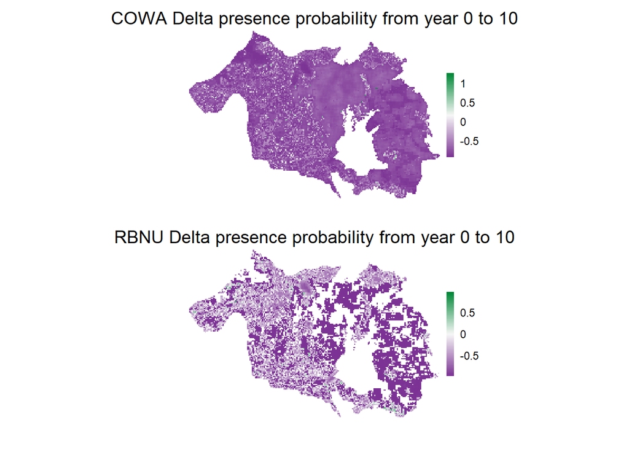

We can also see some of the caribou outputs:

1. Lambda through time

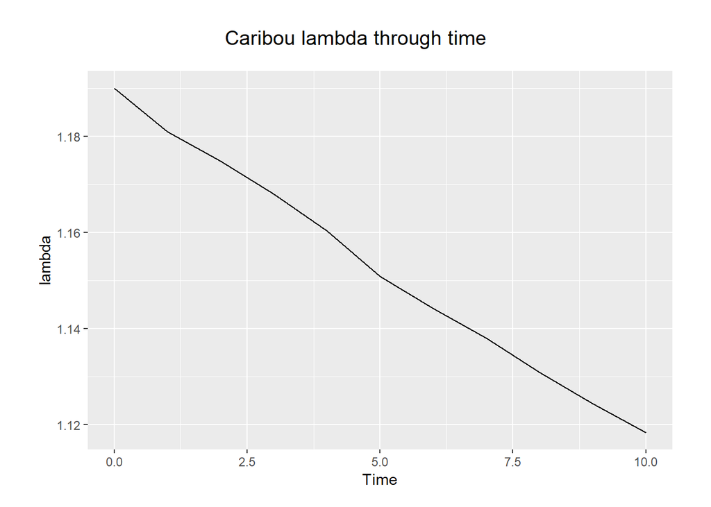

2. Lambda and population size through time

| Lambda | Nt |
| --- | --- |
| 1.190000 | 105102 |
| 1.181013 | 105102 |
| 1.174831 | 105102 |
| 1.167997 | 105102 |
| 1.160262 | 105102 |
| 1.150919 | 105102 |
| 1.144185 | 105102 |
| 1.138022 | 105102 |
| 1.130892 | 105102 |
| 1.124388 | 105102 |
| 1.118415 | 105102 |

### Hands-on

Are you ready to start on SpaDES? You can either play around with these modules (change parameters or change the study the area) or you can start you very own module. For that, you can simply type:

```r
newModule("ModuleName", path = getPaths()$modulePath)
```